# R Notebook

```r
library(tidyverse)
library(lubridate)
```

## Biogeochemistry Variables

Data folder “EDM_Data_Melack” was downloaded ~11:30 Eastern Daylight Time on Oct 26 2021 from UC Davis Box file shared by Shohei Watanabe. This folder contains initial candidate variables for EDM analysis organized in a basic file tree. First we simply read in each file, using package “readr” contained in the meta-package “tidyverse”.

We also make the following parameter definitions to parse out depth zones.

```r
d_sechi <- 30 # Approximate extent of zone of sechi depth dynamics; 30m is approximately the 95th quantile of sechi depth over 1968-present period.
d_euphotic <- 100 # Approximate deepest extent of 1% euphotic zone over 1968-present period
```

The variables are descibed as follows in “Chemical_Data_ReadMe.txt”

THP_LTP.csv Total hydrolyzable Phosphorus (ug L^-1 as P) at Index. Data before 1995 are questionable and not included.

THP_MLTP.csv Total hydrolyzable Phosphorus (ug L^-1 as P) at Mid-lake. Data before 1995 are questionable and not included.

NO3_LTP.csv Nitrate (ug L^-1 as N) at Index from 1968-02-10.

NO3_MLTP.csv Nitrate (ug L^-1 as N) at Mid-lake from 1970-11-17.

TKN_MLTP.csv Total Kjeldahl Nitrogen (ug L^-1 as N) at Mid-lake station from 1989-11-02

TP_MLTP.csv Total Phosphorus (ug L^-1 as P) at Mid-lake station from 2000-08-11

```r
## Secchi Disc Depths
df_Secchi_LTP <- read_csv("./EDM_Data_Melack/Secchi_LTP.csv") # 1967 -
df_Secchi_MLTP <- read_csv("./EDM_Data_Melack/Secchi_MLTP.csv") # 1980 -
## Chlorophyll a
# Col 1 Date: Sampled date
# Col 2 Station_ID: differentiating Index and Mid-lake
# Col 3 Depth: Depth sampled in m.
# Col 4 Chla concentration in ug per Liter.
# Col 5 Flag: code represent the status of data. 1. Good, 2. Estimated, 3. There is potential problem Use with Caution.
# Col 6 & 7 Comments for data if any.
df_Chla_LTP <- read_csv("./EDM_Data_Melack/Chl_LTP.csv") # 1983 -
df_Chla_MLTP <- read_csv("./EDM_Data_Melack/Chl_MLTP.csv") # 1992 -
## Phytoplankton
df_Phyto_LTP <- read_csv("./DATA/Phytoplankton/Phytoplankton_LTP_Depth_Sample.csv")
## NO3
df_NO3_LTP <- read_csv("./EDM_Data_Melack/NO3_LTP.csv") # 1968 -
df_NO3_MLTP <- read_csv("./EDM_Data_Melack/NO3_MLTP.csv") # 1980 -
## THP
df_THP_LTP <- read_csv("./EDM_Data_Melack/THP_LTP.csv") # 1996 -
df_THP_MLTP <- read_csv("./EDM_Data_Melack/THP_LTP.csv") # 1996 -
df_TP_MLTP <- read_csv("./EDM_Data_Melack/THP_LTP.csv") # 1996 -
```

Processing preamble.

```r
start_date <- "1967-01-01"
end_date <- "2021-12-31"

v_dates_2mo <- expand_grid(Year=1967:2020,Month=seq(1,12,by=2)) %>%
  mutate(Day=1) %>%
  mutate(Date=(make_date(Year,Month,Day))) %>%
  pull(Date)

v_dates_3mo <- expand_grid(Year=1967:2020,Month=seq(1,12,by=3)) %>%
  mutate(Day=1) %>%
  mutate(Date=(make_date(Year,Month,Day))) %>%
  pull(Date)

f_date_bin <- function(df,v_dates,date_col=Date,binnable_col=everything()){

  df_binned <- df %>%
    mutate({{date_col}} := cut.Date({{date_col}},breaks=v_dates)) %>%
    mutate({{date_col}} := ymd({{date_col}})) %>%
    right_join(tibble("{{date_col}}" := v_dates)) %>%
    group_by({{date_col}}) %>%
    summarise(across(binnable_col,mean))

# df_binned <- df %>%
#     mutate({{date_col}} := cut.Date({{date_col}},breaks=v_dates)) %>%
#     mutate({{date_col}} := ymd({{date_col}})) %>%
#   right_join(tibble("{{date_col}}" := v_dates))

  return(df_binned)
}
```

Many of the BGC variables aren’t just sampled across time, but also across depth. We attempt to usefully summarise this information based on existing limnological understanding of the lake. We will use a depth-weighted averaging scheme to look at BGC in the “sechi zone”, the “deep euphotic” zone, and possibly the “deep deep” zone of the lake (below the deep chlorophyll maximum). In averaging, we can also address missing values provided that nearby depths are valid proxies.

In the depth sampling of chlorophyll at LTP, most depths are measured most of the time.

```r
df_Chla_LTP %>%
  pull(Depth) %>%
  table()
```

```
.
  0   2   5  10  15  20  30  40  50  60  75  90 105
417 421 419 413 415 417 410 415 420 413 418 416 420
```

Additionally there is high correlation between observations at the nearby depths.

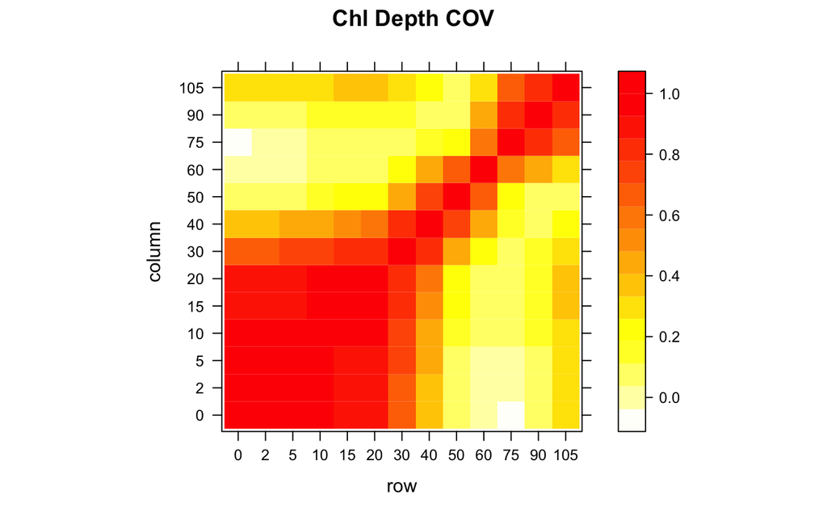

```r
df_Chla_LTP_depth_widened <- df_Chla_LTP %>%
  select(Date,Depth,Chla) %>%
  group_by(Date) %>%
  pivot_wider(names_from = "Depth",values_from="Chla") %>%
  ungroup()
df_Chla_LTP_depth_widened %>%
  select(-Date) %>%
  as.matrix() %>%
  cor(.,use="pair") %>%
  lattice::levelplot(.,main="Chl Depth COV",col.regions=heat.colors(100,rev=T))
```

Now, we also define two similar functions for processing depth resolution of the observations. Above, we defined breaks for “sechi zone” and “euphotic zone”. In one case, we give weight based on the distance between successive depth measurements. In the other, we do no weighting; this is primarily to check that our weighting scheme doesn’t produce odd artifacts.

```r
v_split_depths <- c(0,d_sechi,d_euphotic)
v_split_labels <-  c("sechi","deep_euphotic")

# v_split_depths <- c(0,d_sechi,d_euphotic)
v_accumulate_labels <-  c("sechi","euphotic","lake")

f_depth_split_no_weight <- function(df,obs_col,v_depths=v_split_depths,v_labels=v_split_labels,
                          depth_col=Depth,date_col=Date){

  df_binned <- df %>%
    mutate({{depth_col}} := cut({{depth_col}},breaks=v_depths,labels=v_labels)) %>%
    filter(!is.na({{depth_col}})) %>%
    mutate({{depth_col}} := droplevels({{depth_col}})) %>%
    group_by({{date_col}},{{depth_col}}) %>%
    summarise(across(obs_col,mean)) %>% # this needs to change
    pivot_wider(id_cols = {{date_col}},
                names_from={{depth_col}},
                values_from={{obs_col}},
                names_glue=glue::glue("{.value}_{<<rlang::as_name(enquo(depth_col))>>}", .open = "<<", .close = ">>"))

}

f_depth_split <- function(df,obs_col,v_depths=v_split_depths,v_labels=v_split_labels,
                          depth_col=Depth,date_col=Date){

  df_binned <- df %>%
    select({{date_col}},{{depth_col}},{{obs_col}}) %>%
    # mutate({{depth_col}} := cut({{depth_col}},breaks=v_depths,labels=v_labels)) %>%
    mutate(depth_bin = cut({{depth_col}},breaks=v_depths,labels=FALSE)) %>%
    mutate(depth_min = v_split_depths[depth_bin],depth_max = v_split_depths[depth_bin+1]) %>%
    mutate(depth_bin=factor(depth_bin,labels=v_labels)) %>%
    filter(!is.na(depth_bin)) %>%
    arrange({{date_col}},{{depth_col}}) %>%
    group_by({{date_col}},depth_bin) %>%
    nest(data=c({{depth_col}},{{obs_col}})) %>%
    mutate(data = map(data,function(df) {
      ws = diff( c(depth_min,pull(df,{{depth_col}}),depth_max),lag=2)
      df = df %>% summarise(across(obs_col,~weighted.mean(.x,ws)))
      return(df)
    }
      )) %>%
    unnest(data) %>%
    pivot_wider(id_cols = {{date_col}},
                names_from=depth_bin,
                values_from={{obs_col}},
                # names_glue=glue::glue("{.value}_{<<rlang::as_name(enquo(depth_col))>>}", .open = "<<", .close = ">>"))
                names_glue="{.value}_{depth_bin}")

}
```

The more careful depth averaging yields nearly the same information in the sense of signal correlation, however, there is a mean prescent error on the order of 2-2.5%.

```r
test_1 <- f_depth_split(df_Chla_LTP,obs_col =  "Chla")
test_2 <- f_depth_split_no_weight(df_Chla_LTP,obs_col =  "Chla")
cor(test_1$Chla_deep_euphotic,test_2$Chla_deep_euphotic)
```

```
[1] 0.994047
```

```r
cor(test_1$Chla_sechi,test_2$Chla_sechi)
```

```
[1] 0.9985944
```

```r
mean(abs(test_1$Chla_sechi-test_2$Chla_sechi))/mean(test_2$Chla_sechi)
```

```
[1] 0.02364869
```

Process chlorophyll; note that there are some issues with inconsistent depth sampling we average through, but nearly every sample appears to extend to 90m.

```r
df_3mo_Chla_LTP <- f_depth_split(df_Chla_LTP,obs_col =  "Chla") %>% f_date_bin(v_dates_3mo)
df_2mo_Chla_LTP <-f_depth_split(df_Chla_LTP,obs_col =  "Chla") %>% f_date_bin(v_dates_2mo)
```

Process Secchi

```r
df_Secchi_LTP_reduced <- df_Secchi_LTP %>% mutate(Date=as.Date(Date_Time_Local)) %>% select(-Sample_ID,-Date_Time_Local)
df_3mo_Secchi_LTP <- f_date_bin(df_Secchi_LTP_reduced,v_dates_3mo)
df_2mo_Secchi_LTP <- f_date_bin(df_Secchi_LTP_reduced,v_dates_2mo)
```

```r
date_start_plot <- as.Date("1970-01-01")
date_end_plot <- as.Date("1972-01-01")

g_vis_bin_3mo <- df_3mo_Secchi_LTP %>%
  ggplot(aes(x=Date)) +
  geom_step(aes(y=Secchi_Ave)) +
  geom_point(data=df_Secchi_LTP %>% mutate(Date=as.Date(Date_Time_Local)),aes(y=Secchi_Ave),pch=3) +
  xlim(c(date_start_plot,date_end_plot)) +
  labs(title="3 month bins")

g_vis_bin_2mo <- df_2mo_Secchi_LTP %>%
  ggplot(aes(x=Date)) +
  geom_step(aes(y=Secchi_Ave)) +
  geom_point(data=df_Secchi_LTP %>% mutate(Date=as.Date(Date_Time_Local)),aes(y=Secchi_Ave),pch=3) +
  xlim(c(date_start_plot,date_end_plot)) +
  labs(title="2 month bins")

gridExtra::grid.arrange(g_vis_bin_3mo,g_vis_bin_2mo,nrow=1)
```

[output not shown]

```r
df_NO3_LTP %>%
  pull(Depth) %>%
  table()
```

[output not shown]

```r
v_depths_keep_NO3 <- c(0,2,5,10,15,20,30,40,50,60,75,90)
df_NO3_LTP_reduced <- df_NO3_LTP %>% filter(Depth %in% v_depths_keep_NO3)
```

```r
df_NO3_LTP_depth_widened <- df_NO3_LTP_reduced %>%
  select(Date,Depth,NO3) %>%
  arrange(Depth) %>%
  group_by(Date) %>%
  pivot_wider(names_from = "Depth",values_from="NO3") %>%
  ungroup()

df_NO3_LTP_depth_widened %>%
  select(-Date) %>%
  as.matrix() %>%
  cor(.,use="pair") %>%
  lattice::levelplot(.,main="NO3 Depth Cor",col.regions=heat.colors(100,rev=T))
```

[output not shown]

```r
df_3mo_NO3_LTP <- f_depth_split(df_NO3_LTP_reduced,obs_col =  "NO3") %>% f_date_bin(v_dates_3mo)
df_2mo_NO3_LTP <-f_depth_split(df_NO3_LTP_reduced,obs_col =  "NO3") %>% f_date_bin(v_dates_2mo)
```

Process Phytoplankton to get Cyclotella Counts.

```r
df_Phyto_LTP_reduced <- df_Phyto_LTP %>%
  # select(Date,Depth,Cyclotella_spp_Count) %>%
  # rename(Cyclotella = Cyclotella_spp_Count) %>%
  select(Date,Depth,Cyclotella_spp_Total_Coutnt) %>%
  rename(Cyclotella = Cyclotella_spp_Total_Coutnt) %>%
  filter(complete.cases(.))

df_3mo_Cyclotella_LTP <- f_depth_split(df_Phyto_LTP_reduced,obs_col =  "Cyclotella") %>%
  f_date_bin(v_dates_3mo)
df_2mo_Cyclotella_LTP <- f_depth_split(df_Phyto_LTP_reduced,obs_col =  "Cyclotella") %>% f_date_bin(v_dates_2mo)
```

### Generate BGC data-frames

```r
df_3mo_BGC_LTP <- reduce(
  .x = list(
    df_Secchi_LTP %>% mutate(Date=as.Date(Date_Time_Local)) %>% select(-Sample_ID,-Date_Time_Local) %>% f_date_bin(v_dates_3mo),
    df_Chla_LTP %>% f_depth_split(obs_col =  "Chla") %>% f_date_bin(v_dates_3mo),
    df_NO3_LTP_reduced %>% f_depth_split(obs_col =  "NO3") %>% f_date_bin(v_dates_3mo)
  ),
  .f = full_join,by="Date"
)

save(df_3mo_BGC_LTP,file="./DATA/PROCESSED/_0 3-month BGC.Rdata")
```

```r
df_2mo_BGC_LTP <- reduce(
  .x = list(
    df_Secchi_LTP_reduced %>% f_date_bin(v_dates_2mo),
    df_Chla_LTP %>% f_depth_split(obs_col =  "Chla") %>% f_date_bin(v_dates_2mo),
    df_NO3_LTP_reduced %>% f_depth_split(obs_col =  "NO3") %>% f_date_bin(v_dates_2mo)
  ),
  .f = full_join,by="Date"
)

save(df_2mo_BGC_LTP,file="./DATA/PROCESSED/_0 2-month BGC.Rdata")
```

## Exogenous Variables

### Lake Temperature

```r
df_T_LTP_1 <- read_csv("./EDM_Data_Melack/Temperature_1_LTP.csv") %>%
  filter(INSTRUMENT %in% c("MARTEK","REV_TH","YSI")) %>%
  # select(DATE, `DEPTH (m)`, `TEMP (C)`) %>%
  select(-4) %>%
  rename(Date=1, Depth=2, Temp=3, Instrument = 4)
df_T_LTP_2 <- read_csv("./EDM_Data_Melack/Temperature_2_LTP.csv") %>%
  rename(Date=1, Depth=2, Temp=3) %>%
  mutate(Instrument = "Brancker")
df_T_LTP_3 <- read_csv("./EDM_Data_Melack/Temperature_3_LTP.csv") %>%
  rename(Date=1, Depth=2, Temp=3)
df_T_LTP <- bind_rows(df_T_LTP_1,df_T_LTP_2,df_T_LTP_3)
```

```r
df_T_LTP %>% pull(Depth) %>% table()
```

[output not shown]

Surface - Bottom (2 - 90) Avg Brutt-vasala Avg secchi

```r
v_depths_keep_Temp <- c(0,2,5,10,15,20,30,40,50,60,75,90) # c(0,2,5,10,15,20,30,40,50,60,75,90,98)

df_T_LTP_reduced <- df_T_LTP %>% filter(Depth %in% v_depths_keep_Temp)
```

```r
df_T_LTP_avgs <- f_depth_split(df_T_LTP_reduced,obs_col = "Temp") %>%
  rename(Temp_avg_sechi = Temp_sechi,Temp_avg_deep_euphotic = Temp_deep_euphotic) %>%
  mutate(Temp_delta = Temp_avg_sechi - Temp_avg_deep_euphotic)

df_T_LTP_diffs <- f_depth_split_no_weight(df_T_LTP_reduced,obs_col="Temp",
                                v_depths=c(0,10,60,100),
                                v_labels=c("top","m1","bot")) %>%
  mutate(Temp_delta = Temp_top - Temp_bot)
cor(df_T_LTP_avgs$Temp_delta,df_T_LTP_diffs$Temp_delta,use='pair')
```

```
[1] 0.9874113
```

```r
df_2mo_T_LTP <- df_T_LTP_avgs %>% f_date_bin(v_dates_2mo) %>%
  mutate_at(vars(-Date),.funs = list(~ts(.,frequency=6) %>% na.interp()))
df_3mo_T_LTP <- df_T_LTP_avgs %>% f_date_bin(v_dates_3mo) %>%
  mutate_at(vars(-Date),.funs = list(~ts(.,frequency=4) %>% na.interp()))
save(df_2mo_T_LTP,file="./DATA/PROCESSED/_0 2-month T_LTP.Rdata")
save(df_3mo_T_LTP,file="./DATA/PROCESSED/_0 3-month T_LTP.Rdata")
```

### USGS

Upper Truckee River at South Lake Tahoe, CA UT1 10336610 from 1980 Blackwood Creek near Tahoe City, CA BC1 10336660 from 1974 Ward Creek at Hwy 89 near Tahoe Pines, CA WC8 10336676 from 1972

```
        TS   parameter     statistic     Description
    215686       63680     00008     Turbidity, water, unfiltered, monochrome near infra-red LED light, 780-900 nm, detection angle 90 +-2.5 degrees, formazin nephelometric units (FNU) (Median)
    215687       63680     00002     Turbidity, water, unfiltered, monochrome near infra-red LED light, 780-900 nm, detection angle 90 +-2.5 degrees, formazin nephelometric units (FNU) (Minimum)
    215688       63680     00001     Turbidity, water, unfiltered, monochrome near infra-red LED light, 780-900 nm, detection angle 90 +-2.5 degrees, formazin nephelometric units (FNU) (Maximum)
    234636       00010     00003     Temperature, water, degrees Celsius (Mean)
      7524       00010     00001     Temperature, water, degrees Celsius (Maximum)
      7525       00010     00002     Temperature, water, degrees Celsius (Minimum)
      7526       00010     00008     Temperature, water, degrees Celsius (Median)
      7527       00010     00011     Temperature, water, degrees Celsius (Instantaneous)
      7528       00060     00003     Discharge, cubic feet per second (Mean)
      7529       00095     00003     Specific conductance, water, unfiltered, microsiemens per centimeter at 25 degrees Celsius (Mean)
      7530       80154     00003     Suspended sediment concentration, milligrams per liter (Mean)
      7531       80155     00003     Suspended sediment discharge, short tons per day (Mean)
```

```r
# v_col_keep <- c("datetime","7528_00060_00003","7528_00060_00003_cd")
v_col_keep <- c("datetime")

L_files_USGS_daily <- list(
  Blackwood="./DATA/USGS/USGS_daily_Blackwood_Creek_10336660.txt",
  Upper_Truckee="./DATA/USGS/USGS_daily_Upper_Truckee_River_10336610.txt",
  Ward="./DATA/USGS/USGS_daily_Ward_Creek_10336676.txt"
)


data_USGS <- imap(L_files_USGS_daily,function(file_i,name_i){
  read_delim(file_i,delim="\t",comment="#",na="Ice") %>%
    select(all_of(v_col_keep),ends_with("00060_00003")) %>%
    filter(row_number() > 1) %>%
    set_names(c("Date",paste0("Q_mean_",name_i))) %>%
    mutate(Date = ymd(Date)) %>%
    mutate_at(c(2),as.numeric)
})

df_USGS <- reduce(data_USGS,full_join,by="Date") %>%
  filter(Date >= ymd("1972-10-01"))


df_3mo_USGS <- df_USGS %>% f_date_bin(v_dates_3mo)
df_2mo_USGS <- df_USGS %>% f_date_bin(v_dates_2mo)

save(df_3mo_USGS,file="./DATA/PROCESSED/_0 3-month USGS.Rdata")
save(df_2mo_USGS,file="./DATA/PROCESSED/_0 2-month USGS.Rdata")
```

## Precipitation.

Precipitation and air temperature (National Weather Service via Truckee River Operating Agreement; https://www.troa.net/tis/): Daily precipitation and average of max/min temperature at Tahoe City from 1937 TROA – site 150017 (Lake Tahoe) variables 1616 and 8.

https://www.troa.net/tis/?interval=day&type=1&cat=1&sid=150017&did11=1616&did13=8&format=tab&sdate=01-JAN-1960&edate=01-Apr-2022

```r
L_files_weather_daily <- list(
  TROA_precip = "./DATA/TROA_NET/troa_Lake_Tahoe_WM_precip.txt"
)

data_weather <- map(L_files_weather_daily,function(file_i){
  read_delim(file_i,
             delim="\t") %>%
             # col_names = c("Date","precip_in"),
             # skip=1) %>%
    # pivot_longer(-1,names_to="Month",values_to=name_i) %>%
    rename_at(1,~"Date") %>%
    rename_at(2,~"precip") %>%
    select(1:2) %>%
    mutate(Date = mdy(Date)) %>%
    mutate_at(2,~replace(., is.na(.), 0))
})

df_weather <- reduce(data_weather,full_join,by="Date") %>%
  filter(Date >= ymd("1967-01-01"))

df_3mo_weather <- df_weather %>% f_date_bin(v_dates_3mo)
df_2mo_weather <- df_weather %>% f_date_bin(v_dates_2mo)

save(df_3mo_weather,file="./DATA/PROCESSED/_0 3-month weather.Rdata")
save(df_2mo_weather,file="./DATA/PROCESSED/_0 2-month weather.Rdata")
```

### Climate Indices

```r
L_files_indices_monthly <- list(
  SOI="./DATA/NOAA_INDICES/soi.data",
  NINO_34="./DATA/NOAA_INDICES/nina34.anom.data"
)


data_indices <- imap(L_files_indices_monthly,function(file_i,name_i){
  read_table(file_i,
             col_names = c("Year",as.character(1:12)),
             skip=1,na="-99.99",comment="#") %>%
    pivot_longer(-1,names_to="Month",values_to=name_i) %>%
    mutate(Date = ymd(paste(Year,Month,"15",sep="-"))) %>%
    select(Date,name_i)
})

df_indices <- reduce(data_indices,full_join,by="Date") %>%
  filter(Date >= ymd("1967-01-01"))


df_3mo_indices <- df_indices %>% f_date_bin(v_dates_3mo)
df_2mo_indices <- df_indices %>% f_date_bin(v_dates_2mo)

save(df_3mo_indices,file="./DATA/PROCESSED/_0 3-month indices.Rdata")
save(df_2mo_indices,file="./DATA/PROCESSED/_0 2-month indices.Rdata")
```